# Loading and preprocessing the data

## Loading and preprocessing the data

First import the data using read.csv(), into a data.frame called **activity**

```r
## Read CSV data
activity <- read.csv("activity.csv")
## Convert activity$date using as.Date
activity$date <- as.Date(activity$date)
```

Data import and preprocessing are now complete.

## What is mean total number of steps taken per day?

```r
## Split **activity** by date
bydate <- split(activity[,1], activity$date)
## Apply *sum()* to every element of **bydate**.
bydate <- sapply(bydate, sum)
```

Now can use this processed data to draw a histogram of the information

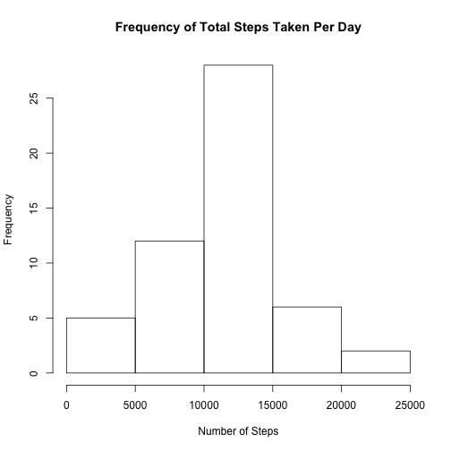

```r
hist(bydate, main = "Frequency of Total Steps Taken Per Day", xlab = "Number of Steps")
```

The mean and median for this data can then be found:

```r
summary(bydate)[3:4]
```

```
## Median   Mean
##  10760  10770
```

## What is the average daily activity pattern?

Make a time-series plot of mean of steps taken per 5-minute time block, averaged over all days

To do this, we will split the data into groups based on the interval data, then find the mean for each of these groups. We can then plot the resulting data for mean steps per time period.

```r
## Split activty$steps information by activity$interval
bytime <- split(activity[,1], activity$interval)
##
bytime <- sapply(bytime, function(x) mean(x,na.rm=TRUE))
```

We can now produce a time-series plot of the average steps taken per time interval:

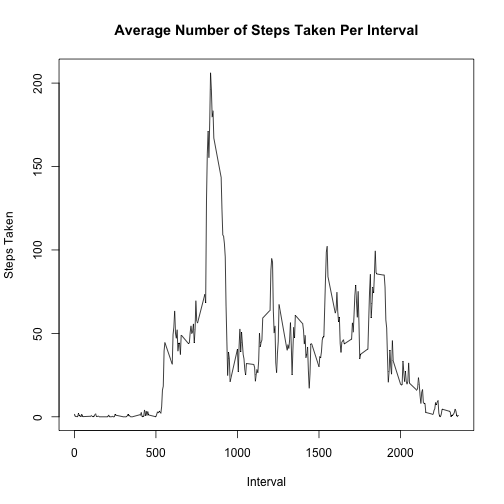

```r
plot(names(bytime), bytime, type = "l", main = "Average Number of Steps Taken Per Interval", ylab = "Steps Taken", xlab = "Interval" )
```

We can now find the time with the most average steps taken:

```r
names(which.max(bytime))
```

```
## [1] "835"
```

## Imputing missing values

1. Find the total number of NAs in the data.frame

Here I sum the number TRUE responses to *is.na()* called on the data.frame

```r
sum(is.na(activity))
```

```
## [1] 2304
```

Thus, there are 2304 missing values in the data.frame.

1. I choose to replace NA values with the average steps per taken during that interval

3. To do this, we will first create a new data frame identical to the first. We will then loop through the new dataframe to find the rows with NAs. When we find one, we rewrite the steps data for that row with the data from the **bytime** data that we found earlier.

```r
# Creates new *data.frame* **activity2**, identical to **activity**
activity2 <- activity
# Loops through rows of **activity2**, finds if each row is NA, then converts all NAs to the
# step data found in **bytime**
for (i in 1:nrow(activity2)){
        if (is.na(activity2[i,1])){
                activity2[i,1] <- bytime[[as.character(activity2[i,3])]]
        }
}
```

1. Create a histogram of the new data

```r
## Split **activity** by date
bydate2 <- split(activity2[,1], activity2$date)
## Apply *sum()* to every element of **bydate**.
bydate2 <- sapply(bydate2, sum)
```

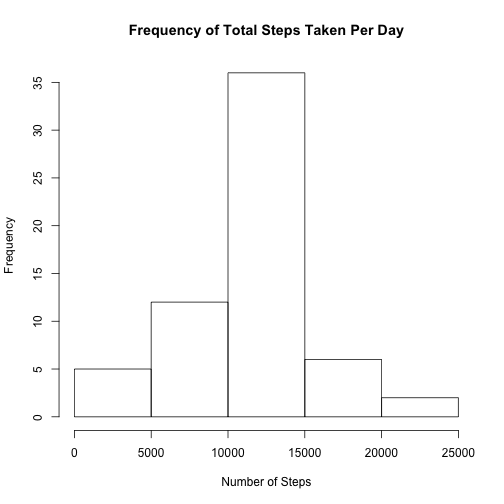

## Are there differences in activity patterns between weekdays and weekends?

To complete this step, I first split the **activity2** data by weekend/weekday status, then use the same *sapply()* technique as in previous steps to find the average steps per time interval for each day group.

```r
# Add a new column to the activity2 dataframe, a 2 level factor with labels weekend/weekday
activity2$dtype <- factor(0:1, labels = c("weekday","weekend"))
# Loop through the rows of the dataframe correct the weekend/weekday column
for (i in 1:nrow(activity2)){
        if (weekdays(activity2[i,2], TRUE) %in% c("Sat", "Sun")){
                activity2[i,4] <- "weekend"
        } else {
                activity2[i,4] <- "weekday"
        }
}
# Create new list compare, equal to splitting activity2 by the weekend/weekday column
compare <- split(activity2[,c(1,3,4)], activity2$dtype)
# Find the mean for each time interval separately for each weekday/weekend
days <- compare[[1]]
days <- split(days[,1], days[,2])
days <- sapply(days, mean)
ends <- compare[[2]]
ends <- split(ends[,1], ends[,2])
ends <- sapply(ends, mean)
```

This completes the data analysis step. We can now create the plot.

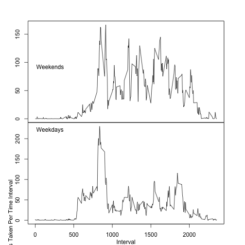

```r
par(mfrow=c(2,1), mar = c(0,4,3,3))
plot(names(ends), ends, type = "l", xaxt = "n", ylab = "")
box(col = "grey40")
par(mar = c(3,4,0,3))
plot(names(days), days, type = "l", ylab = "")
box(col = "grey40")
mtext("Interval", side = 1, line = 2)
mtext("Average Steps Taken", side = 4, line = 0, adj = -9)
mtext("Steps Taken Per Time Interval", side = 2, line = 2, adj = -1.5)
        mtext("Weekends", side = 3, line = 7.5, adj = .05)
mtext("Weekdays", side = 3, line = -1.5, adj = .05)
```

It looks like the user took more steps later in the day on the weekends than during the week. Thanks for reading my project!